# Supplement for Planting the seed for sound change: evidence from real-time MRI of velum kinematics in German

## 2.1 Checks

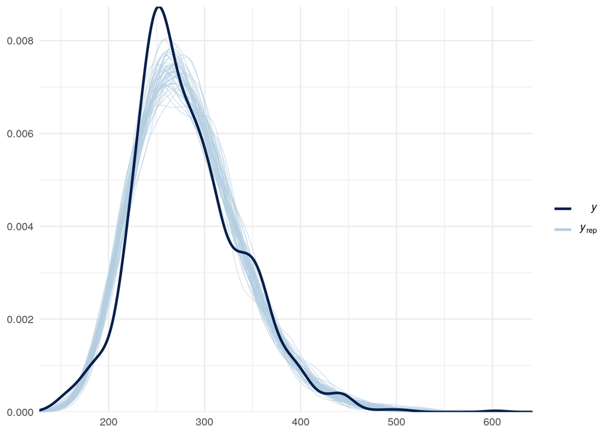

```r
pp_check(dur, nsamples = 50) + theme_minimal()
```

For the sensitivity analysis we followed the method introduced in Betancourt (2018). In the following plot, $s$ (posterior shrinkage) indicates the contribution of the data to the posterior (values closer to 1 are better). $z$ (posterior z-score) indicates how close the inference is to the data generating process (lower values are better). An ideal fit should have $s$ = 1 and $z$ = 0. Posteriors with high $s$ and high $z$ indicate overfit (the data dominate the posterior), while posteriors with low $s$ and low $z$ indicate that the model is poorly identified (the data is not contributing to the model and the priors dominate).

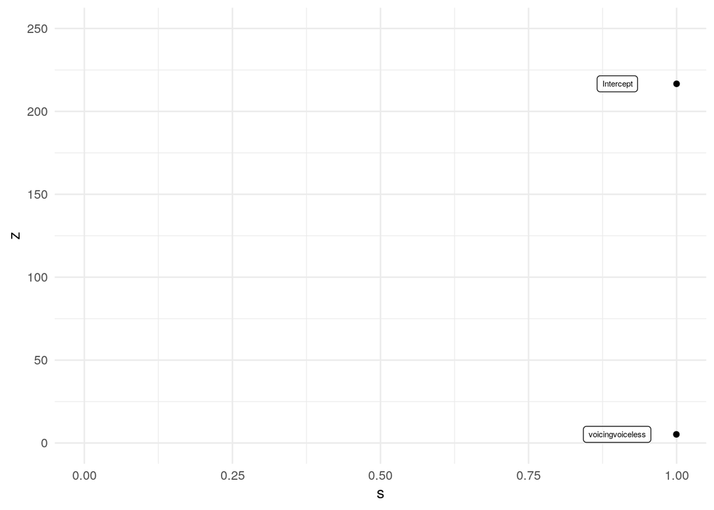

```r
dur_fixed <- fixef(dur) %>% as_tibble(rownames = "term")

dur_fixed %>%
  mutate(
    theta = c(0, 0),
    sigma_prior = c(3, 1),
    # it's called here std.error but is the standard deviation
    z = abs((Estimate - theta) / Est.Error),
    s = 1 - (Est.Error^2 / sigma_prior^2)
  ) %>%
  ggplot(aes(s, z, label = term)) +
  geom_point() +
  geom_label(nudge_x = -0.1, size = 2, alpha = 0.5) +
  xlim(0, 1) + ylim(0, 250) +
  theme_minimal()
```

# 3 Velum gesture onset

See velum gesture duration for prior specification.

```r
# create the dependent variable
subdat$DV <- -(subdat$velumopening_gesture_on - subdat$Vokal_off)*1000

# full model
onset <- brms::brm(
  DV ~ voicing +
    (1 + voicing | speaker) +
    (1 + voicing | word),
  data = subdat,
  family = lognormal(),
  prior = c(prior(normal(0, 3), class = Intercept),
            prior(normal(0, 1), class = b, coef = voicingvoiceless),
            prior(cauchy(0, 0.1), class = sd),
            prior(cauchy(0, 0.1), class = sigma),
            prior(lkj(2), class = cor)),
  seed = my.seed,
  iter = 4000,
  warmup = 2000,
  chains = 4,
  cores = core.num,
  control = list(adapt_delta = 0.99,
                 max_treedepth = 20),
  file = "./rtMRI-velum/models/onset",
  save_all_pars = TRUE
)
```

```
## recompiling to avoid crashing R session
```

```r
onset
```

```
##  Family: lognormal
##   Links: mu = identity; sigma = identity
## Formula: DV ~ voicing + (1 + voicing | speaker) + (1 + voicing | word)
##    Data: subdat (Number of observations: 1365)
## Samples: 4 chains, each with iter = 4000; warmup = 2000; thin = 1;
##          total post-warmup samples = 8000
##
## Group-Level Effects:
## ~speaker (Number of levels: 35)
##                                 Estimate Est.Error l-95% CI u-95% CI Rhat
## sd(Intercept)                       0.17      0.02     0.13     0.22 1.00
## sd(voicingvoiceless)                0.03      0.02     0.00     0.09 1.00
## cor(Intercept,voicingvoiceless)    -0.21      0.39    -0.84     0.65 1.00
##                                 Bulk_ESS Tail_ESS
## sd(Intercept)                       1992     3448
## sd(voicingvoiceless)                1339     2749
## cor(Intercept,voicingvoiceless)     6310     5205
##
## ~word (Number of levels: 30)
##                                 Estimate Est.Error l-95% CI u-95% CI Rhat
## sd(Intercept)                       0.23      0.04     0.17     0.32 1.00
## sd(voicingvoiceless)                0.05      0.03     0.00     0.13 1.00
## cor(Intercept,voicingvoiceless)    -0.39      0.37    -0.93     0.49 1.00
##                                 Bulk_ESS Tail_ESS
## sd(Intercept)                       2193     3821
## sd(voicingvoiceless)                1333     1861
## cor(Intercept,voicingvoiceless)     4879     4686
##
## Population-Level Effects:
##                  Estimate Est.Error l-95% CI u-95% CI Rhat Bulk_ESS Tail_ESS
## Intercept            4.63      0.06     4.52     4.74 1.00     1427     2639
## voicingvoiceless     0.12      0.03     0.05     0.18 1.00     4824     4270
##
## Family Specific Parameters:
##       Estimate Est.Error l-95% CI u-95% CI Rhat Bulk_ESS Tail_ESS
## sigma     0.31      0.01     0.29     0.32 1.00     9877     5453
##
## Samples were drawn using sampling(NUTS). For each parameter, Bulk_ESS
## and Tail_ESS are effective sample size measures, and Rhat is the potential
## scale reduction factor on split chains (at convergence, Rhat = 1).
```

```r
# reduced/null model
onset_null <- brms::brm(
  DV ~
    (1 + voicing | speaker) +
    (1 + voicing | word),
  data = subdat,
  family = lognormal(),
  prior = c(prior(normal(0, 3), class = Intercept),
            prior(cauchy(0, 0.1), class = sd),
            prior(cauchy(0, 0.1), class = sigma),
            prior(lkj(2), class = cor)),
  seed = my.seed,
  iter = 4000,
  warmup = 2000,
  chains = 4,
  cores = core.num,
  control = list(adapt_delta = 0.99,
                 max_treedepth = 20),
  file = "./rtMRI-velum/models/onset_null",
  save_all_pars = TRUE
)
```

```
## recompiling to avoid crashing R session
```

```r
# calculate the Bayes factor of the difference between the full and null models
brms::bayes_factor(onset, onset_null)
```

```
## Iteration: 1
## Iteration: 2
## Iteration: 3
## Iteration: 4
## Iteration: 5
## Iteration: 6
## Iteration: 7
## Iteration: 1
## Iteration: 2
## Iteration: 3
## Iteration: 4
## Iteration: 5
```

```
## Estimated Bayes factor in favor of onset over onset_null: 6.09439
```

```r
# calculate the marginal posteriors of the full model
onset_post <- brms::posterior_samples(onset, pars="b_") %>%
  dplyr::mutate(
    nd = exp(b_Intercept),
    nt = exp(b_Intercept) * exp(b_voicingvoiceless)
  ) %>%
  dplyr::select(nd, nt) %>%
  tidyr::gather(context, DV)
```

## 3.1 Checks

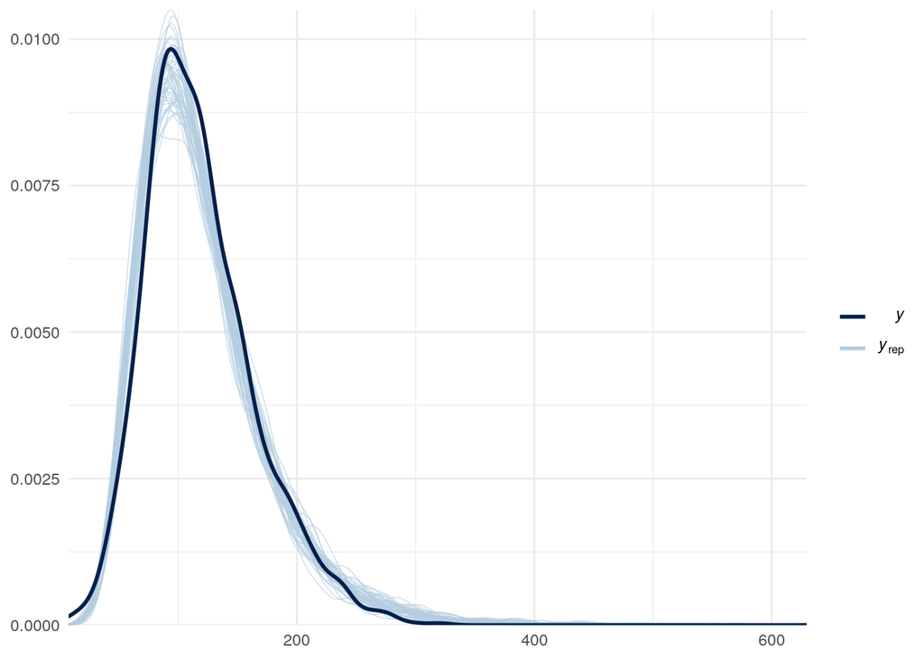

```r
pp_check(onset, nsamples = 50) + theme_minimal()
```

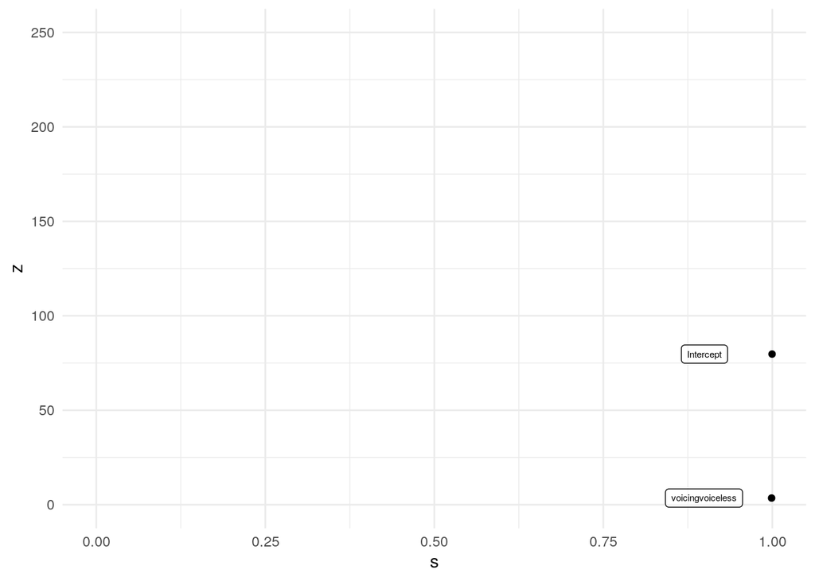

```r
onset_fixed <- fixef(onset) %>% as_tibble(rownames = "term")

onset_fixed %>%
  mutate(
    theta = c(0, 0),
    sigma_prior = c(3, 1),
    # it's called here std.error but is the standard deviation
    z = abs((Estimate - theta) / Est.Error),
    s = 1 - (Est.Error^2 / sigma_prior^2)
  ) %>%
  ggplot(aes(s, z, label = term)) +
  geom_point() +
  geom_label(nudge_x = -0.1, size = 2, alpha = 0.5) +
  xlim(0, 1) + ylim(0, 250) +
  theme_minimal()
```

# 4 Velum gesture peak (timing)

The BRM for the time point of the velum gesture peak was built using a Gaussian distribution; unlike the other measures of timing, the time point of the velum gesture peak is not expected to follow a one-sided (positive support) distribution, since the peak can potentially occur before or after the vowel offset. The following distributions were used as weakly informative priors (on the milliseconds scale): for the intercept (corresponding to ND), $Normal(0, 200)$; for the effect of voicing (when NT), $Normal(0, 100)$. These correspond to a belief that the intercept is between -400 and 400 ms from the vowel offset, and that the time changes by -200 to 200 ms in the NT context, at 95% confidence. For the model standard deviation and the random intercept standard deviation we used $HalfCauchy(0, 5)$, which corresponds to a 95% HDI = [0, 127] ms.

```r
inverseCDF(c(0.025, 0.975), phcauchy, sigma = 5)
```

```
## [1]   0.1964676 127.2584987
```

For the correlation between random effects, an $LKJ(2)$ distribution.

```r
# create the dependent variable
subdat$DV <- (subdat$velumopening_maxcon_on - subdat$Vokal_off)*1000

# full model
gest.max <- brms::brm(
  DV ~ voicing +
    (1 + voicing | speaker) +
    (1 + voicing | word),
  data = subdat,
  family = gaussian(),
  prior = c(prior(normal(0, 200), class = Intercept),
            prior(normal(0, 100), class = b, coef = voicingvoiceless),
            prior(cauchy(0, 5), class = sd),
            prior(cauchy(0, 5), class = sigma),
            prior(lkj(2), class = cor)),
  seed = my.seed,
  iter = 6000,
  warmup = 3000,
  chains = 4,
  cores = core.num,
  control = list(adapt_delta = 0.99,
                 max_treedepth = 20),
  file = "./rtMRI-velum/models/gest_max",
  save_all_pars = TRUE
)
gest.max
```

```
##  Family: gaussian
##   Links: mu = identity; sigma = identity
## Formula: DV ~ voicing + (1 + voicing | speaker) + (1 + voicing | word)
##    Data: subdat (Number of observations: 1365)
## Samples: 4 chains, each with iter = 6000; warmup = 3000; thin = 1;
##          total post-warmup samples = 12000
##
## Group-Level Effects:
## ~speaker (Number of levels: 35)
##                                 Estimate Est.Error l-95% CI u-95% CI Rhat
## sd(Intercept)                      15.97      2.12    12.34    20.60 1.00
## sd(voicingvoiceless)               13.25      1.95     9.83    17.45 1.00
## cor(Intercept,voicingvoiceless)    -0.62      0.12    -0.81    -0.36 1.00
##                                 Bulk_ESS Tail_ESS
## sd(Intercept)                       3775     6145
## sd(voicingvoiceless)                3350     5750
## cor(Intercept,voicingvoiceless)     4495     6496
##
## ~word (Number of levels: 30)
##                                 Estimate Est.Error l-95% CI u-95% CI Rhat
## sd(Intercept)                      15.45      2.63    10.84    21.10 1.00
## sd(voicingvoiceless)                3.65      2.21     0.24     8.66 1.00
## cor(Intercept,voicingvoiceless)    -0.20      0.39    -0.86     0.60 1.00
##                                 Bulk_ESS Tail_ESS
## sd(Intercept)                       4210     5937
## sd(voicingvoiceless)                1965     3280
## cor(Intercept,voicingvoiceless)    11008     7531
##
## Population-Level Effects:
##                  Estimate Est.Error l-95% CI u-95% CI Rhat Bulk_ESS Tail_ESS
## Intercept           45.86      4.38    37.12    54.38 1.00     2478     4656
## voicingvoiceless   -25.69      3.11   -31.86   -19.62 1.00     4152     6324
##
## Family Specific Parameters:
##       Estimate Est.Error l-95% CI u-95% CI Rhat Bulk_ESS Tail_ESS
## sigma    18.52      0.37    17.82    19.28 1.00    17060     9155
##
## Samples were drawn using sampling(NUTS). For each parameter, Bulk_ESS
## and Tail_ESS are effective sample size measures, and Rhat is the potential
## scale reduction factor on split chains (at convergence, Rhat = 1).
```

```r
# reduced/null model
gest.max_null <- brms::brm(
  DV ~
    (1 + voicing | speaker) +
    (1 + voicing | word),
  data = subdat,
  family = gaussian(),
  prior = c(prior(normal(0, 200), class = Intercept),
            prior(cauchy(0, 5), class = sd),
            prior(cauchy(0, 5), class = sigma),
            prior(lkj(2), class = cor)),
  seed = my.seed,
  iter = 6000,
  warmup = 3000,
  chains = 4,
  cores = core.num,
  control = list(adapt_delta = 0.99,
                 max_treedepth = 20),
  file = "./rtMRI-velum/models/gest_max_null",
  save_all_pars = TRUE
)
# calculate the Bayes factor of the difference between the full and null models
brms::bayes_factor(gest.max, gest.max_null)
```

```
## Iteration: 1
## Iteration: 2
## Iteration: 3
## Iteration: 4
## Iteration: 5
## Iteration: 6
## Iteration: 7
## Iteration: 8
## Iteration: 1
## Iteration: 2
## Iteration: 3
## Iteration: 4
## Iteration: 5
## Iteration: 6
## Iteration: 7
## Iteration: 8
```

```
## Estimated Bayes factor in favor of gest.max over gest.max_null: 1835353.90706
```

```r
# calculate the marginal posteriors of the full model
gest.max_post <- brms::posterior_samples(gest.max, pars="b_") %>%
  dplyr::mutate(
    nd = b_Intercept,
    nt = b_Intercept + b_voicingvoiceless
  ) %>%
  dplyr::select(nd, nt) %>%
  tidyr::gather(context, DV)
```

## 4.1 Checks

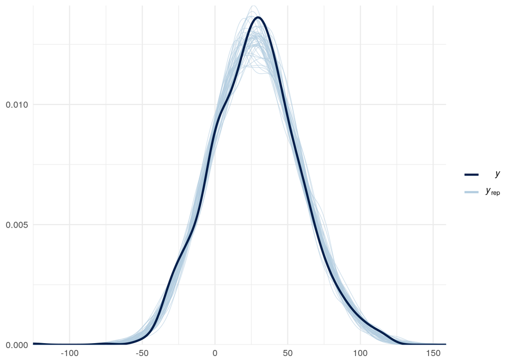

```r
pp_check(gest.max, nsamples = 50) + theme_minimal()
```

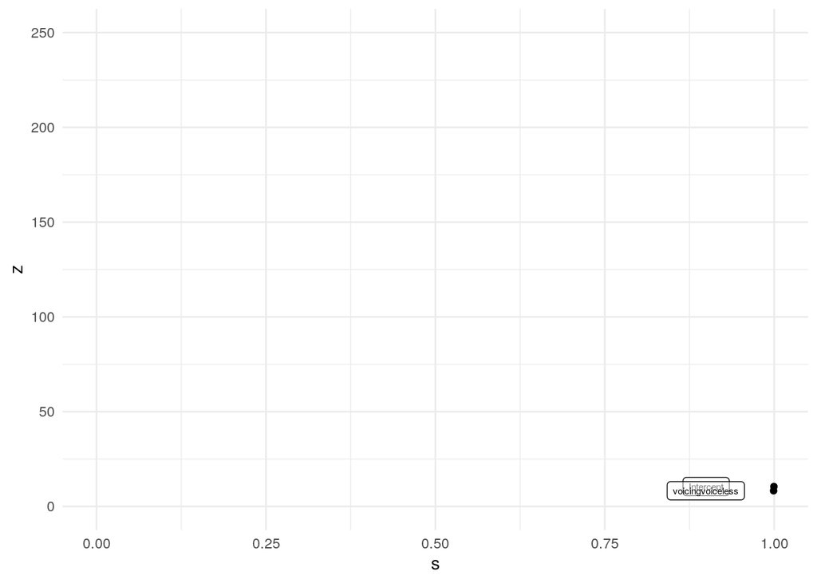

```r
gest.max_fixed <- fixef(gest.max) %>% as_tibble(rownames = "term")

gest.max_fixed %>%
  mutate(
    theta = c(0, 0),
    sigma_prior = c(200, 100),
    # it's called here std.error but is the standard deviation
    z = abs((Estimate - theta) / Est.Error),
    s = 1 - (Est.Error^2 / sigma_prior^2)
  ) %>%
  ggplot(aes(s, z, label = term)) +
  geom_point() +
  geom_label(nudge_x = -0.1, size = 2, alpha = 0.5) +
  xlim(0, 1) + ylim(0, 250) +
  theme_minimal()
```

# 5 Velum gesture offset

See velum gesture duration for prior specification.

```r
# create the dependent variable
subdat$DV <- (subdat$velumopening_gesture_off - subdat$Vokal_off)*1000

# full model
offset <- brms::brm(
  DV ~ voicing +
    (1 + voicing | speaker) +
    (1 + voicing | word),
  data = subdat,
  family = lognormal(),
  prior = c(prior(normal(0, 3), class = Intercept),
            prior(normal(0, 1), class = b, coef = voicingvoiceless),
            prior(cauchy(0, 0.1), class = sd),
            prior(cauchy(0, 0.1), class = sigma),
            prior(lkj(2), class = cor)),
  seed = my.seed,
  iter = 6000,
  warmup = 3000,
  chains = 4,
  cores = core.num,
  control = list(adapt_delta = 0.99,
                 max_treedepth = 20),
  file = "./rtMRI-velum/models/offset",
  save_all_pars = TRUE
)
```

```
## recompiling to avoid crashing R session
```

```r
offset
```

```
##  Family: lognormal
##   Links: mu = identity; sigma = identity
## Formula: DV ~ voicing + (1 + voicing | speaker) + (1 + voicing | word)
##    Data: subdat (Number of observations: 1365)
## Samples: 4 chains, each with iter = 6000; warmup = 3000; thin = 1;
##          total post-warmup samples = 12000
##
## Group-Level Effects:
## ~speaker (Number of levels: 35)
##                                 Estimate Est.Error l-95% CI u-95% CI Rhat
## sd(Intercept)                       0.15      0.02     0.12     0.20 1.00
## sd(voicingvoiceless)                0.11      0.02     0.08     0.15 1.00
## cor(Intercept,voicingvoiceless)    -0.42      0.15    -0.68    -0.09 1.00
##                                 Bulk_ESS Tail_ESS
## sd(Intercept)                       4598     6415
## sd(voicingvoiceless)                4772     7862
## cor(Intercept,voicingvoiceless)     6016     7747
##
## ~word (Number of levels: 30)
##                                 Estimate Est.Error l-95% CI u-95% CI Rhat
## sd(Intercept)                       0.05      0.02     0.02     0.09 1.00
## sd(voicingvoiceless)                0.07      0.02     0.03     0.12 1.00
## cor(Intercept,voicingvoiceless)    -0.15      0.34    -0.76     0.53 1.00
##                                 Bulk_ESS Tail_ESS
## sd(Intercept)                       2182     4699
## sd(voicingvoiceless)                1409     2940
## cor(Intercept,voicingvoiceless)     1627     2582
##
## Population-Level Effects:
##                  Estimate Est.Error l-95% CI u-95% CI Rhat Bulk_ESS Tail_ESS
## Intercept            5.28      0.03     5.21     5.34 1.00     2568     5089
## voicingvoiceless    -0.28      0.03    -0.34    -0.22 1.00     2990     5502
##
## Family Specific Parameters:
##       Estimate Est.Error l-95% CI u-95% CI Rhat Bulk_ESS Tail_ESS
## sigma     0.16      0.00     0.15     0.17 1.00    17295     8738
##
## Samples were drawn using sampling(NUTS). For each parameter, Bulk_ESS
## and Tail_ESS are effective sample size measures, and Rhat is the potential
## scale reduction factor on split chains (at convergence, Rhat = 1).
```

```r
# reduced/null model
offset_null <- brms::brm(
  DV ~
    (1 + voicing | speaker) +
    (1 + voicing | word),
  data = subdat,
  family = lognormal(),
  prior = c(prior(normal(0, 3), class = Intercept),
            prior(cauchy(0, 0.1), class = sd),
            prior(cauchy(0, 0.1), class = sigma),
            prior(lkj(2), class = cor)),
  seed = my.seed,
  iter = 6000,
  warmup = 3000,
  chains = 4,
  cores = core.num,
  control = list(adapt_delta = 0.99,
                 max_treedepth = 20),
  file = "./rtMRI-velum/models/offset_null",
  save_all_pars = TRUE
)
```

```
## recompiling to avoid crashing R session
```

```r
# calculate the Bayes factor of the difference between the full and null models
brms::bayes_factor(offset, offset_null)
```

```
## Iteration: 1
## Iteration: 2
## Iteration: 3
## Iteration: 4
## Iteration: 5
## Iteration: 6
## Iteration: 7
## Iteration: 8
## Iteration: 9
## Iteration: 1
## Iteration: 2
## Iteration: 3
## Iteration: 4
## Iteration: 5
## Iteration: 6
## Iteration: 7
```

```
## Estimated Bayes factor in favor of offset over offset_null: 120143815.60406
```

```r
# calculate the marginal posteriors of the full model
offset_post <- brms::posterior_samples(offset, pars="b_") %>%
  dplyr::mutate(
    nd = exp(b_Intercept),
    nt = exp(b_Intercept) * exp(b_voicingvoiceless)
  ) %>%
  dplyr::select(nd, nt) %>%
  tidyr::gather(context, DV)
```

## 5.1 Checks

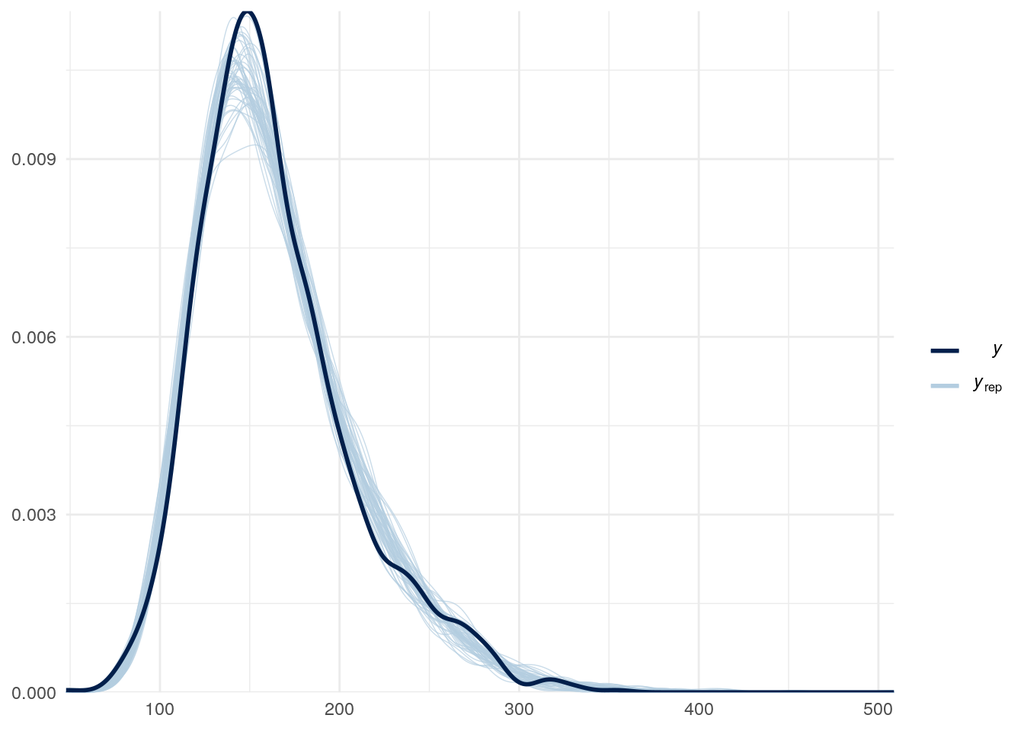

```r
pp_check(offset, nsamples = 50) + theme_minimal()
```

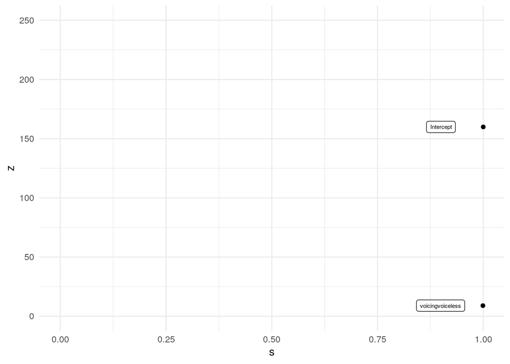

```r
offset_fixed <- fixef(offset) %>% as_tibble(rownames = "term")

offset_fixed %>%
  mutate(
    theta = c(0, 0),
    sigma_prior = c(3, 1),
    # it's called here std.error but is the standard deviation
    z = abs((Estimate - theta) / Est.Error),
    s = 1 - (Est.Error^2 / sigma_prior^2)
  ) %>%
  ggplot(aes(s, z, label = term)) +
  geom_point() +
  geom_label(nudge_x = -0.1, size = 2, alpha = 0.5) +
  xlim(0, 1) + ylim(0, 250) +
  theme_minimal()
```